# Facial Recognition Software

Jason Renn

6/12/2019

## A Brave New World

[video not shown]

- What are the arguments for the use of this technology to aid governments and police forces? What are the dangers?
- How would you respond if you lived in a society that used technology to monitor your movements?
- What are some fictional examples where governments use technology to control their citizens?
- Do you understand how this technology works?

## Behind the Curtain

Read/watch some of these pieces and come up with a short summary explaining how this technology works. Try writing explainations that anyone could understand, from your eight-year-old brother to your eighty-year-old grandmother.

- Omoyiwola, Damilola. [Machine Learning on Facial Recognition](https://medium.com/datadriveninvestor/machine-learning-on-facial-recognition-b3dfba5625a7). *Medium*. 26 Oct. 2018.

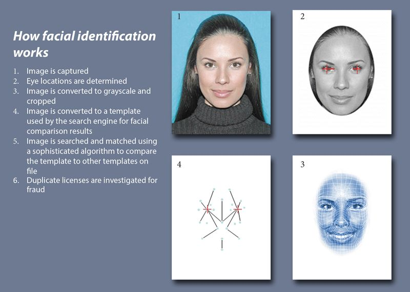

[video not shown]

## Writing Prompt

Imagine that you live in a society where cameras capture all of your activities – at least in public places. You have no anonymity. How does your behavior change? Are you a better citizen? Do you want to want to interact with other people? Include in your response a brief description of how facial recognition technology works and how you think it may change in the next ten years.